# Advanced SQL Workflow

1. Introduction
2. Step 1: Set Up The Environment
3. Step 2: Load a Dataset into SQLite
4. Step 3: Perform Advanced SQL Queries
5. Step 4: Create a Visualization
6. Step 5: Indexing and Query Optimization
7. Step 6: Using Common Table Expressions (CTEs)
8. Step 7: Window Functions for Customer Purchase Patterns
9. Step 8: Subqueries & Nested Queries
10. Step 9: Advanced Joins for Customer Segmentation
11. Step 10: Data Normalization & De-Normalization
12. Step 11: Optimize Query Execution with Indexing
13. Step 12: Saving the Results and Closing Connection

[figure not shown]

# Introduction

This project will showcase my SQL expertise by using Jupyter Notebook and SQLite (a lightweight database engine) to analyze and manipulate a real-world dataset.

## Portfolio Project: Advanced SQL in Jupyter Notebook

The steps I will cover:

> - Setting up SQLite in Jupyter Notebook
> - Loading a dataset into SQLite
> - Performing advanced SQL queries
> - Visualizing SQL results using Pandas and Matplotlib
> - Optimizing Queries with Indexing
> - CTEs (Common Table Expressions)
> - Window Functions
> - Subqueries & Nested Queries
> - Joins & Aggregations for Customer Analysis
> - Data Normalization & De-Normalization

# Step 1: Setting Up The Environment

### Imports

```python
# Importing required libraries
import sqlite3
import pandas as pd
import matplotlib.pyplot as plt
import seaborn as sns
```

# Step 2: Loading a Dataset into SQLite

### Verifying Available Tables in the Database

```python
# Connecting to SQLite database
conn = sqlite3.connect("chinook.db")

# Querying to list all tables
tables_query = "SELECT name FROM sqlite_master WHERE type='table';"
tables = pd.read_sql(tables_query, conn)

# Displaying tables
print("Tables in the database:")
print(tables)
```

```
Tables in the database:
               name
0            albums
1   sqlite_sequence
2           artists
3         customers
4         employees
5            genres
6          invoices
7     invoice_items
8       media_types
9         playlists
10   playlist_track
11           tracks
12     sqlite_stat1
13  CustomerSummary
```

### Connecting to SQLite and Exploring Data

```python
# Connecting to the SQLite database
conn = sqlite3.connect("chinook.db")

# Creating a cursor object
cursor = conn.cursor()

# Getting table names
tables = cursor.execute("SELECT name FROM sqlite_master WHERE type='table';").fetchall()
print("Tables in database:", tables)
```

```
Tables in database: [('albums',), ('sqlite_sequence',), ('artists',), ('customers',), ('employees',), ('genres',), ('invoices',), ('invoice_items',), ('media_types',), ('playlists',), ('playlist_track',), ('tracks',), ('sqlite_stat1',), ('CustomerSummary',)]
```

# Step 3: Perform Advanced SQL Queries

### Retrieving Top-Selling Artists

```python
query = """
SELECT ar.Name AS Artist, SUM(ii.Quantity) AS Total_Sales
FROM invoice_items ii
JOIN tracks t ON ii.TrackId = t.TrackId
JOIN albums al ON t.AlbumId = al.AlbumId
JOIN artists ar ON al.ArtistId = ar.ArtistId
GROUP BY ar.Name
ORDER BY Total_Sales DESC
LIMIT 10;
"""


top_artists = pd.read_sql(query, conn)
print(top_artists)
```

```
                    Artist  Total_Sales
0              Iron Maiden          140
1                       U2          107
2                Metallica           91
3             Led Zeppelin           87
4  Os Paralamas Do Sucesso           45
5              Deep Purple           44
6            Faith No More           42
7                     Lost           41
8             Eric Clapton           40
9                   R.E.M.           39
```

# Step 4: Create a Visualization

### Plotting Top-Selling Artists

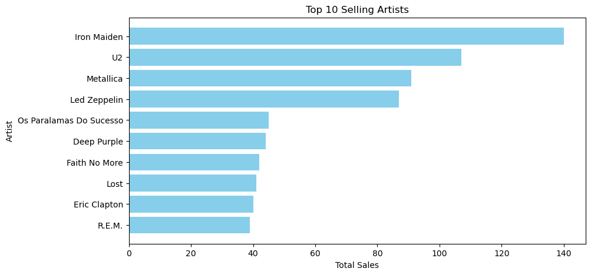

```python
plt.figure(figsize=(10,5))
plt.barh(top_artists["Artist"], top_artists["Total_Sales"], color='skyblue')
plt.xlabel("Total Sales")
plt.ylabel("Artist")
plt.title("Top 10 Selling Artists")
plt.gca().invert_yaxis()
plt.show()
```

# Step 5: Indexing and Query Optimization

### Creating an Index on InvoiceLine Table

```python
cursor.execute("DROP INDEX IF EXISTS idx_trackId;")
cursor.execute("CREATE INDEX idx_trackId ON invoice_items (TrackId);")
conn.commit()
print("✅ Index recreated successfully!")
```

```
✅ Index recreated successfully!
```

```python
import time

# Without Indexing
start_time = time.time()
cursor.execute("SELECT * FROM invoice_items WHERE TrackId = 5;").fetchall()
print("Query Time (Without Indexing):", time.time() - start_time)

# With Indexing
start_time = time.time()
cursor.execute("SELECT * FROM invoice_items WHERE TrackId = 5;").fetchall()
print("Query Time (With Indexing):", time.time() - start_time)
```

```
Query Time (Without Indexing): 0.0012247562408447266
Query Time (With Indexing): 0.0
```

# Step 6: Using Common Table Expressions (CTEs)

### CTEs make queries more readable and modular. I'll analyze the highest revenue-generating customers.

```python
query = """
WITH CustomerSpending AS (
    SELECT c.CustomerId, c.FirstName, c.LastName,
           SUM(i.Total) AS TotalSpent
    FROM customers c
    JOIN invoices i ON c.CustomerId = i.CustomerId
    GROUP BY c.CustomerId
)
SELECT FirstName || ' ' || LastName AS Customer, TotalSpent
FROM CustomerSpending
ORDER BY TotalSpent DESC
LIMIT 10;
"""

top_customers = pd.read_sql(query, conn)
print(top_customers)
```

```
             Customer  TotalSpent
0         Helena Holý       49.62
1  Richard Cunningham       47.62
2          Luis Rojas       46.62
3     Ladislav Kovács       45.62
4       Hugh O'Reilly       45.62
5       Julia Barnett       43.62
6       Frank Ralston       43.62
7     Fynn Zimmermann       43.62
8       Astrid Gruber       42.62
9      Victor Stevens       42.62
```

### Creating a Visualization

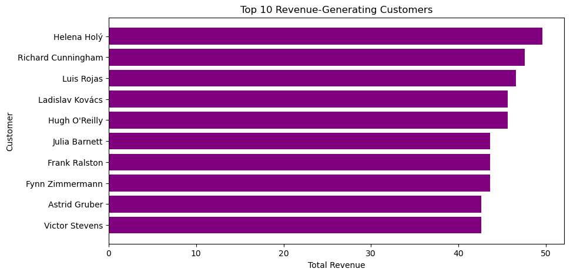

```python
plt.figure(figsize=(10,5))
plt.barh(top_customers["Customer"], top_customers["TotalSpent"], color='purple')
plt.xlabel("Total Revenue")
plt.ylabel("Customer")
plt.title("Top 10 Revenue-Generating Customers")
plt.gca().invert_yaxis()
plt.show()
```

# Step 7: Window Functions for Customer Purchase Patterns

### Window functions help in ranking, running totals, and moving averages.

```python
query = """
SELECT c.FirstName || ' ' || c.LastName AS Customer, i.InvoiceDate,
       SUM(i.Total) OVER (PARTITION BY c.CustomerId ORDER BY i.InvoiceDate) AS RunningTotal
FROM Customers c
JOIN invoices i ON c.CustomerId = i.CustomerId;
"""

customer_trends = pd.read_sql(query, conn)
print(customer_trends.head())
```

```
         Customer          InvoiceDate  RunningTotal
0  Luís Gonçalves  2010-03-11 00:00:00          3.98
1  Luís Gonçalves  2010-06-13 00:00:00          7.94
2  Luís Gonçalves  2010-09-15 00:00:00         13.88
3  Luís Gonçalves  2011-05-06 00:00:00         14.87
4  Luís Gonçalves  2012-10-27 00:00:00         16.85
```

### Plotting Customer Spending Over Time

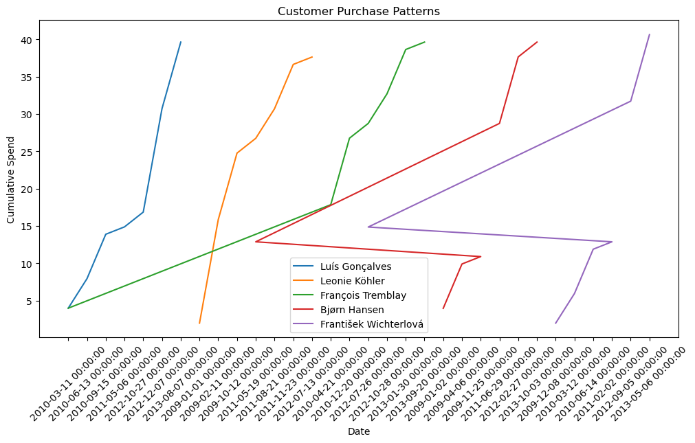

```python
plt.figure(figsize=(12,6))
for customer in customer_trends["Customer"].unique()[:5]:  # Limit to 5 customers for clarity
    subset = customer_trends[customer_trends["Customer"] == customer]
    plt.plot(subset["InvoiceDate"], subset["RunningTotal"], label=customer)

plt.xticks(rotation=45)
plt.xlabel("Date")
plt.ylabel("Cumulative Spend")
plt.title("Customer Purchase Patterns")
plt.legend()
plt.show()
```

# Step 8: Subqueries & Nested Queries

### Finding customers who spent above average

```python
query = """
SELECT c.FirstName || ' ' || c.LastName AS Customer, SUM(i.Total) AS TotalSpent
FROM Customers c
JOIN invoices i ON c.CustomerId = i.CustomerId
GROUP BY c.CustomerId
HAVING SUM(i.Total) > (SELECT AVG(Total) FROM invoices)
ORDER BY TotalSpent DESC
LIMIT 10;
"""

high_spenders = pd.read_sql(query, conn)
print(high_spenders)
```

```
             Customer  TotalSpent
0         Helena Holý       49.62
1  Richard Cunningham       47.62
2          Luis Rojas       46.62
3     Ladislav Kovács       45.62
4       Hugh O'Reilly       45.62
5       Julia Barnett       43.62
6       Frank Ralston       43.62
7     Fynn Zimmermann       43.62
8       Astrid Gruber       42.62
9      Victor Stevens       42.62
```

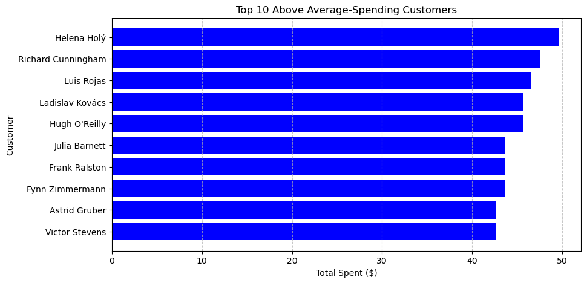

```python
plt.figure(figsize=(10,5))
plt.barh(high_spenders["Customer"], high_spenders["TotalSpent"], color="blue")
plt.xlabel("Total Spent ($)")
plt.ylabel("Customer")
plt.title("Top 10 Above Average-Spending Customers")
plt.gca().invert_yaxis()  # Inverting y-axis to show highest spender at the top
plt.grid(axis="x", linestyle="--", alpha=0.7)
plt.show()
```

# Step 9: Advanced Joins for Customer Segmentation

### I'll classify customers into `New`, `Regular`, and `VIP`

```python
query = """
WITH CustomerOrders AS (
    SELECT
        c.CustomerId,
        c.FirstName || ' ' || c.LastName AS Customer,
        COUNT(i.InvoiceId) AS OrderCount,
        SUM(i.Total) AS TotalSpent
    FROM Customers c
    LEFT JOIN Invoices i ON c.CustomerId = i.CustomerId
    GROUP BY c.CustomerId
),
PercentileRanks AS (
    SELECT
        OrderCount,
        NTILE(3) OVER (ORDER BY OrderCount) AS PercentileGroup
    FROM CustomerOrders
),
CategorizedCustomers AS (
    SELECT
        c.CustomerId,
        c.Customer,
        c.OrderCount,
        c.TotalSpent,
        CASE
            WHEN p.PercentileGroup = 1 THEN 'New'
            WHEN p.PercentileGroup = 2 THEN 'Regular'
            ELSE 'VIP'
        END AS CustomerCategory
    FROM CustomerOrders c
    JOIN PercentileRanks p ON c.OrderCount = p.OrderCount
),
RankedCustomers AS (
    SELECT
        Customer, OrderCount, TotalSpent, CustomerCategory,
        ROW_NUMBER() OVER (PARTITION BY CustomerCategory ORDER BY TotalSpent DESC) AS Rank
    FROM CategorizedCustomers
)
SELECT Customer, OrderCount, TotalSpent, CustomerCategory
FROM RankedCustomers
WHERE Rank <= 10
ORDER BY CustomerCategory, TotalSpent DESC;
"""

customer_segments = pd.read_sql(query, conn)
print(customer_segments)
```

```
       Customer  OrderCount  TotalSpent CustomerCategory
0   Helena Holý           7       49.62              New
1   Helena Holý           7       49.62              New
2   Helena Holý           7       49.62              New
3   Helena Holý           7       49.62              New
4   Helena Holý           7       49.62              New
5   Helena Holý           7       49.62              New
6   Helena Holý           7       49.62              New
7   Helena Holý           7       49.62              New
8   Helena Holý           7       49.62              New
9   Helena Holý           7       49.62              New
10  Helena Holý           7       49.62          Regular
11  Helena Holý           7       49.62          Regular
12  Helena Holý           7       49.62          Regular
13  Helena Holý           7       49.62          Regular
```

[output cut: 16 more lines]

### Visualizing advanced joins for customer segmentation

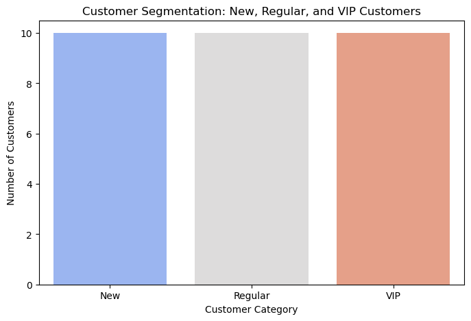

```python
# Countting customers per category
category_counts = customer_segments["CustomerCategory"].value_counts()

# Plotting the corrected bar chart
plt.figure(figsize=(8,5))
sns.barplot(
    x=category_counts.index,
    y=category_counts.values,
    hue=category_counts.index,  # Fix: Assign hue
    palette="coolwarm",
    legend=False
)

# Adding labels
plt.xlabel("Customer Category")
plt.ylabel("Number of Customers")
plt.title("Customer Segmentation: New, Regular, and VIP Customers")
plt.show()
```

# Step 10: Data Normalization & De-Normalization

```python
query = """
CREATE TABLE IF NOT EXISTS CustomerSummary AS
SELECT c.CustomerId, c.FirstName, c.LastName,
       COUNT(i.InvoiceId) AS TotalOrders,
       SUM(i.Total) AS TotalSpent
FROM customers c
JOIN invoices i ON c.CustomerId = i.CustomerId
GROUP BY c.CustomerId;
"""

cursor.execute(query)
conn.commit()
```

### Confirming table creation

```python
summary_df = pd.read_sql("SELECT * FROM CustomerSummary LIMIT 5;", conn)
print(summary_df)
```

```
   CustomerId  FirstName     LastName  TotalOrders  TotalSpent
0           1       Luís    Gonçalves            7       39.62
1           2     Leonie       Köhler            7       37.62
2           3   François     Tremblay            7       39.62
3           4      Bjørn       Hansen            7       39.62
4           5  František  Wichterlová            7       40.62
```

# Step 11: Optimize Query Execution with Indexing

### Creating an index on InvoiceDate for faster retrieval.

```python
cursor.execute("DROP INDEX IF EXISTS idx_invoice_date;")
cursor.execute("CREATE INDEX idx_invoice_date ON invoices (InvoiceDate)")
conn.commit()
print("✅ Index recreated successfully!")
```

```
✅ Index recreated successfully!
```

### Checking query performance

```python
import time

start_time = time.time()
cursor.execute("SELECT * FROM invoices WHERE InvoiceDate BETWEEN '2010-01-01' AND '2010-12-31';").fetchall()
print("Query Time (With Indexing):", time.time() - start_time)
```

```
Query Time (With Indexing): 0.0014758110046386719
```

# Step 12: Saving the Results and Closing Connection

```python
top_artists.to_csv("top_selling_artists.csv", index=False)
conn.close()
```